# Selecting interesting objects using CIGALE physical properties

[figure not shown]

As covered in our introduction to using the HELP virtual observatory server (VOX), we can easily search the HELP database for catalogues in images. In this example, we show how you can do similar searches, but using CIGALE properties rather than positions. One of the advantages of HELP is that it covers a large area, and with a larger area, you can get larger statistical samples of the rarer objects.

In this notebook, we will search the entire HELP database for some galaxies with extreme starformation and get the corresponding SPIRE cutouts.

```python
!pip install pyvo
```

```
     |████████████████████████████████| 808kB 5.7MB/s
```

```python
from astropy.io import ascii, fits
import numpy as np
from astropy.table import Table
import pylab as plt
import seaborn as sns
%matplotlib inline
from astropy import wcs
import pyvo as vo
```

First, create the TAP service using [PyVO](https://pyvo.readthedocs.io/en/latest/)

```python
service = vo.dal.TAPService("https://herschel-vos.phys.sussex.ac.uk/__system__/tap/run/tap")
```

As before, we need to create a query, so:

```python
resultset= service.search("SELECT TOP 100 ra,dec,redshift,cigale_mstar,cigale_sfr FROM herschelhelp.main WHERE cigale_sfr>1000")
```

```python
masterlist=resultset.to_table()
```

```python
masterlist.show_in_notebook()
```

*Table length=100*

| idx | ra deg | dec deg | redshift | cigale_mstar Msun | cigale_sfr Msun / yr |
| --- | --- | --- | --- | --- | --- |
| 0 | 34.6715089475648 | -5.64677315829761 | 5.5069 | 189901422274.742 | 1497.14628391181 |
| 1 | 34.7214719475648 | -5.65702015829761 | 5.1541 | 439717232811.725 | 2592.40844298865 |
| 2 | 34.8559762522776 | -5.69354112477323 | 4.1005 | 449923925549.177 | 1588.63468495625 |
| 3 | 35.0222152722776 | -5.69805032477323 | 4.2907 | 799333947897.97 | 5045.7118616998 |
| 4 | 34.9233084422776 | -5.60976520477323 | 5.6961 | 135131688898.356 | 5462.43158380247 |
| 5 | 35.0984050822776 | -5.51291523477323 | 5.1875 | 633300196639.846 | 1725.04141562314 |
| 6 | 34.6088506122776 | -5.46179850477323 | 4.1559 | 1809691425872.29 | 4797.29912286647 |
| 7 | 34.7898939475648 | -5.42053215829761 | 1.9407 | 1633228166190.24 | 1571.92375035589 |
| 8 | 34.8067338722776 | -5.35714472477323 | 2.9219 | 262978332262.599 | 1540.89465885952 |
| 9 | 34.8919648322776 | -5.34949297477323 | 2.8803 | 1364555930395.42 | 3619.57801552597 |
| 10 | 34.9350279475648 | -5.23579515829761 | 5.5878 | 39502900281.5883 | 1087.58841628607 |
| 11 | 35.2255119475648 | -5.80290615829762 | 3.7632 | 406959308136.167 | 1103.98605142256 |
| 12 | 35.1835389475648 | -5.73958815829761 | 4.5042 | 593236497030.535 | 1602.42365491299 |
| 13 | 35.3909650422776 | -5.81190011477323 | 1.877 | 2174825041572.36 | 2097.83103916779 |
| 14 | 35.2058528730314 | -5.54575028537423 | 4.2979 | 733028434993.243 | 1957.64582775986 |
| 15 | 35.6529233022776 | -5.64781026477323 | 2.8518 | 175000659329.127 | 1109.76505721406 |
| 16 | 35.5107039475648 | -5.56411215829761 | 2.7811 | 174837658438.832 | 1114.41373064963 |
| 17 | 35.5920774685735 | -5.5664786902912 | 2.2201 | 144383633793.247 | 1310.37760246103 |
| 18 | 35.1453549475648 | -5.34494115829762 | 4.7254 | 248881447432.875 | 1326.45569815482 |
| 19 | 35.4081347722776 | -5.44344290477323 | 5.7446 | 2366149415441.07 | 6267.24256980812 |
| 20 | 35.3188729475648 | -5.34646315829761 | 5.0969 | 427536638253.521 | 12357.2772583364 |
| 21 | 35.1233584522776 | -5.17298078477323 | 2.658 | 407490714991.295 | 1060.7713303599 |
| 22 | 35.5321425322776 | -5.31074318477323 | 2.7153 | 237283875750.296 | 1650.73939180245 |
| 23 | 35.6350796822776 | -5.37861774477323 | 3.1984 | 241024752834.531 | 1192.27002757693 |
| 24 | 35.6156722322776 | -5.13076963477323 | 1.0448 | 107872729745.113 | 1770.10404893357 |
| 25 | 34.6320449475648 | -5.10477015829762 | 4.157 | 511058748815.404 | 1631.15205728139 |
| 26 | 34.5398173122776 | -5.03342352477323 | 2.8353 | 188435484765.029 | 1272.10449442896 |
| 27 | 34.5343513922776 | -4.97925629477323 | 2.8276 | 1130620469548.15 | 2981.44407316261 |
| 28 | 35.0087127422776 | -5.01724400477323 | 1.7836 | 130544935192.487 | 1178.48403138048 |
| 29 | 34.8470674622776 | -4.86356870477323 | 2.6134 | 2156313508146.11 | 2081.60922436172 |

[output cut: 70 more lines]

Lets look at the marginalised distributions

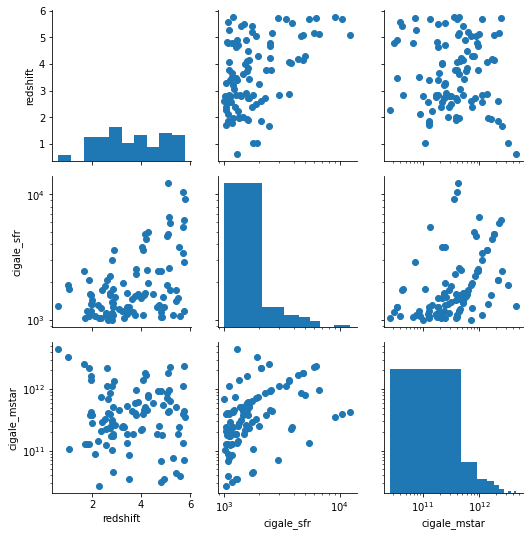

```python
g=sns.PairGrid(masterlist[['redshift','cigale_sfr','cigale_mstar']].to_pandas())
g.map_diag(plt.hist)
g.map_upper(plt.scatter)
g.map_lower(plt.scatter)

g.axes[0,1].set_xscale('log')
g.axes[0,2].set_xscale('log')
g.axes[1,0].set_yscale('log')
g.axes[2,0].set_yscale('log')
```

Lets look at the object that has an SFR of over 12000 $M_{\odot}/yr$

[figure not shown]

**Authors**: Peter Hurley

The Herschel Extragalactic Legacy Project, (HELP), is a European Commission Research Executive Agency funded project under the SP1-Cooperation, Collaborative project, Small or medium-scale focused research project, FP7-SPACE-2013-1 scheme, Grant Agreement Number 607254.